# Log Transform

Hongyu Dai

2021/10/8

# Introduction

It is common in the analysis of biological data to log transform data representing concentrations or data representing dose response.

In this blog, I am to answer a series of questions related to the transformation of data. I will use both analytic methods and simulation to answer the questions.

# Setup

1. Geometic Means = $\sqrt[n]{x_1 \cdot x_2 \cdots x_n}$. The sample size used subsequently in this blog is too large for the formula to be used in R, so I will use the logarithm first and then exponentiate to calculate the geometric mean.
2. The logarithmized variable must be greater than 0.

# Part 1

## Answer

### Distribution 1

*X* ∼ GAMMA(shape = 3, scale = 1)

1. For Gamma distribution,

$$Mean = Shape*Scale$$

```r
x = seq(0, 10, by = 0.01)
mean1 <- 3*1
median1 <- qgamma(0.5,shape = 3, scale = 1)
```

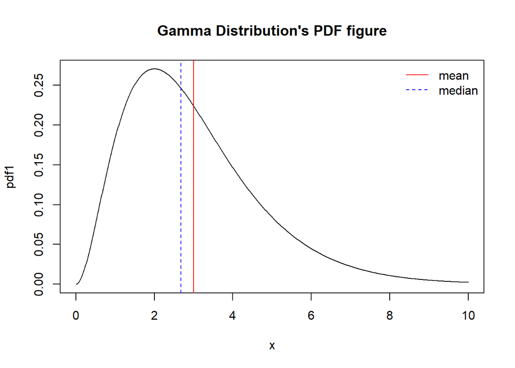

```r
pdf1 <- dgamma(x, shape = 3, scale = 1)

# plot pdf figure
plot(x,pdf1,main='Gamma Distribution\'s PDF figure',type='l')
abline(v=mean1,col='red')
abline(v=median1,col='blue',lty=2)
legend("topright",c("mean","median"),col=c("red","blue"),lty=c(1,2),bty = "n")
```

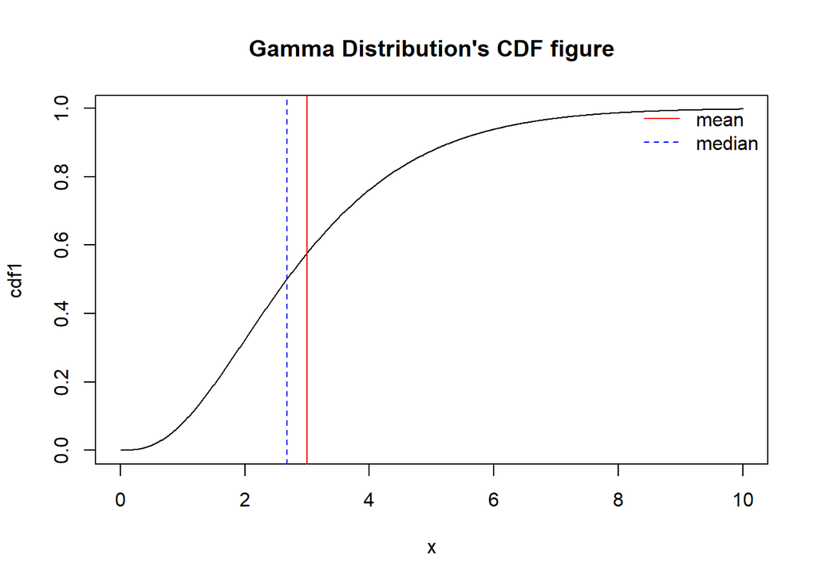

```r
cdf1 <- pgamma(x, shape = 3, scale = 1)

# plot cdf figure
plot(x,cdf1,main='Gamma Distribution\'s CDF figure',type='l')
abline(v=mean1,col='red')
abline(v=median1,col='blue',lty=2)
legend("topright",c("mean","median"),col=c("red","blue"),lty=c(1,2),bty = "n")
```

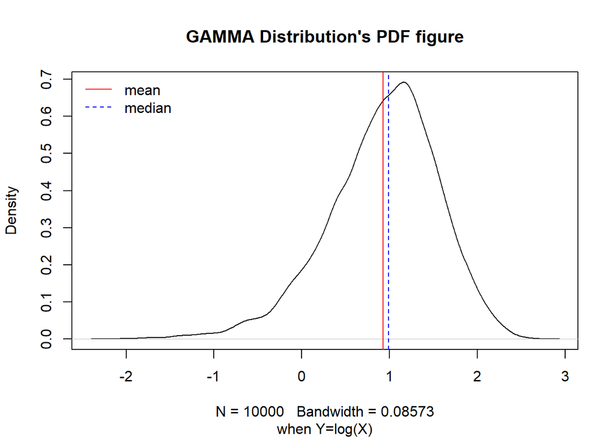

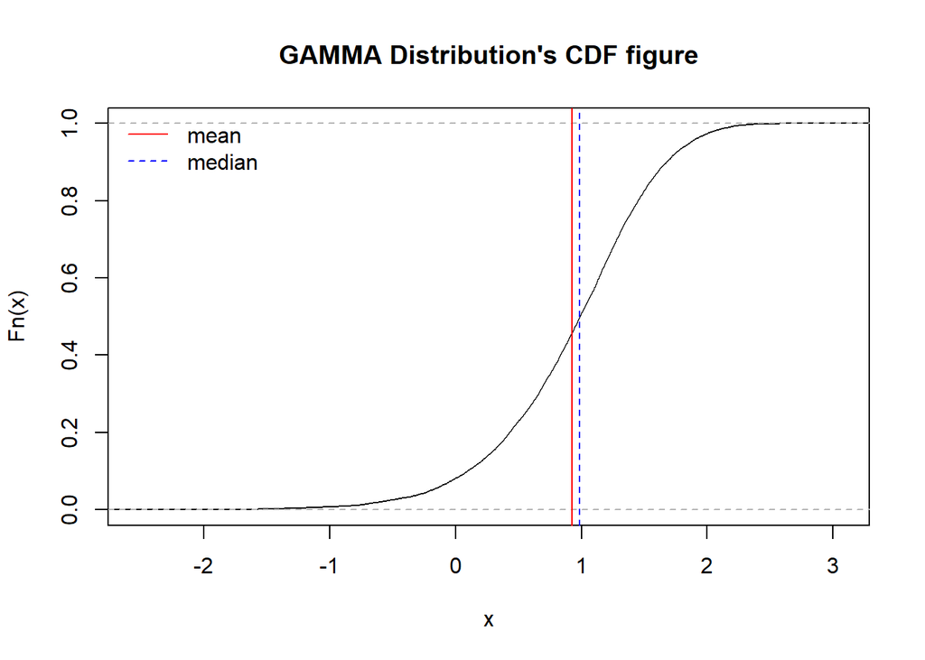

```r
gamma2<-function(times,shape, scale,title1,title2){
X <- rgamma(times,shape, scale)
Y <- log(X)
plot(density(Y),type='l',main=title1,sub='when Y=log(X)')
abline(v=mean(Y),col='red')
abline(v=median(Y),col='blue',lty=2)
legend("topleft",c("mean","median"),col=c("red","blue"),lty=c(1,2),bty = "n")

plot(ecdf(Y),main=title2)
abline(v=mean(Y),col='red')
abline(v=median(Y),col='blue',lty=2)
legend("topleft",c("mean","median"),col=c("red","blue"),lty=c(1,2),bty = "n")
}

gamma2(10000,3,1,title1='GAMMA Distribution\'s PDF figure',title2='GAMMA Distribution\'s CDF figure')
```

3 & 4.

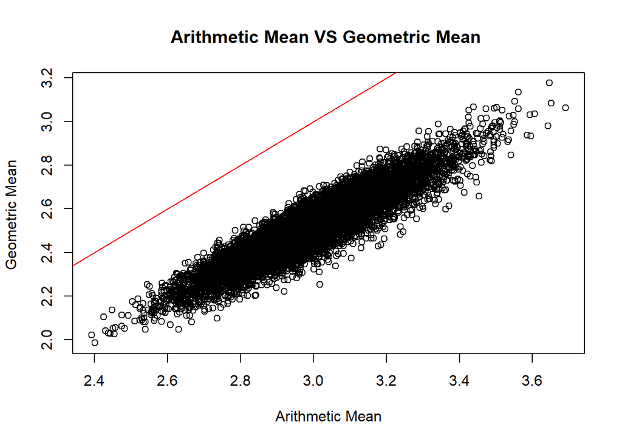

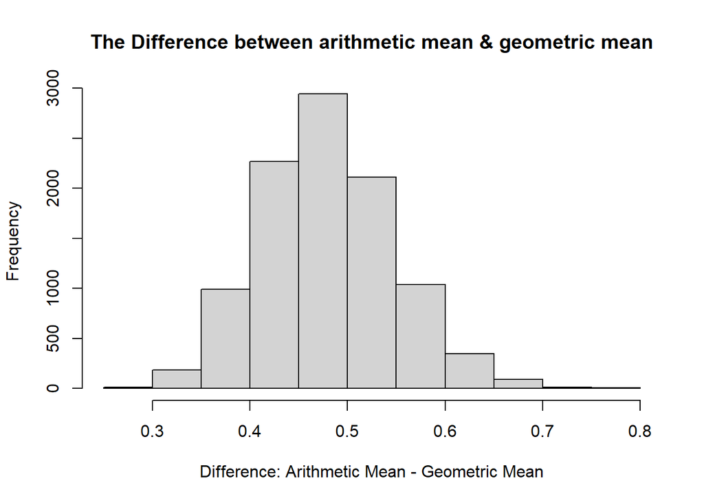

```r
gamma34<-function(n,size,shape, scale){

x=as.data.frame(replicate(n,rgamma(size,shape, scale)))

# arithmetic mean & ge mean
ar_mean <- colMeans(x)
ge_mean <- exp(colMeans(log(x)))

plot(x=ar_mean,y=ge_mean,main='Arithmetic Mean VS Geometric Mean ',xlab = "Arithmetic Mean",  ylab = "Geometric Mean ")
abline(0,1,col='red')

hist(ar_mean-ge_mean,main= 'The Difference between arithmetic mean & geometric mean',xlab='Difference: Arithmetic Mean - Geometric Mean')
}

gamma34(10000,size=100,shape = 3, scale = 1)
```

### Distribution 2

*X* ∼ LOG NORMAL(*μ* = − 1, *σ* = 1)

1. For log normal distribution,

$$Mean=exp(μ+σ^2/2)$$

$$Median=exp(μ)$$

```r
x2<-seq(0,5,0.01)
mean2<-exp(-1+1^2/2)
median2<-exp(-1)
```

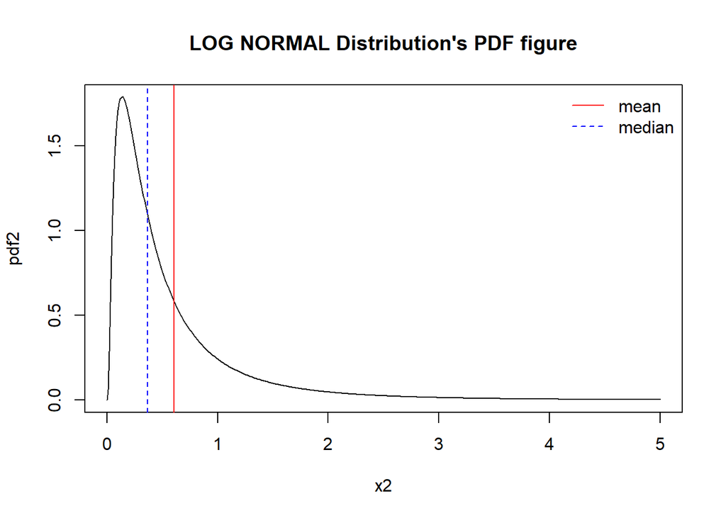

```r
pdf2 <- dlnorm(x2,-1,1)

plot(x2,pdf2,main='LOG NORMAL Distribution\'s PDF figure',type='l')
abline(v=mean2,col='red')
abline(v=median2,col='blue',lty=2)
legend("topright",c("mean","median"),col=c("red","blue"),lty=c(1,2),bty = "n")
```

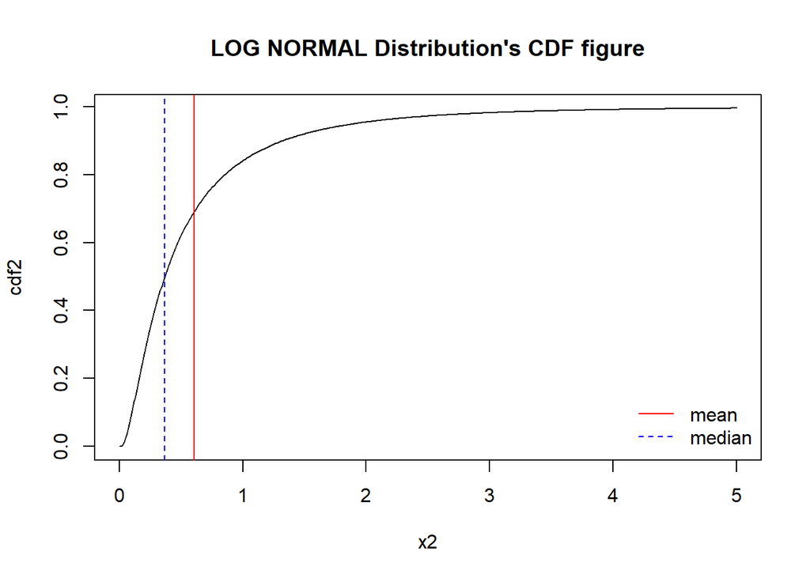

```r
cdf2 <- plnorm(x2,-1,1)

plot(x2,cdf2,main='LOG NORMAL Distribution\'s CDF figure',type='l')
abline(v=mean2,col='red')
abline(v=median2,col='blue',lty=2)
legend("bottomright",c("mean","median"),col=c("red","blue"),lty=c(1,2),bty = "n")
```

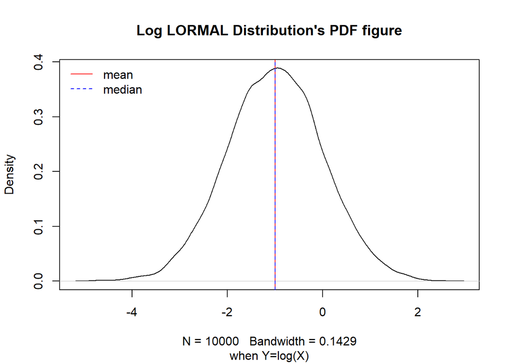

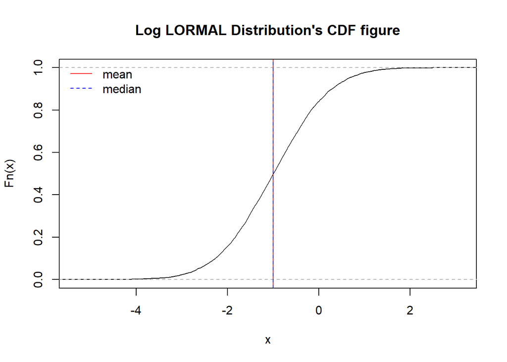

```r
lnorm2<-function(times,μ,σ,title1,title2){
X <- rlnorm(times,μ,σ)
Y <- log(X)
plot(density(Y),type='l',main=title1,sub='when Y=log(X)')
abline(v=mean(Y),col='red')
abline(v=median(Y),col='blue',lty=2)
legend("topleft",c("mean","median"),col=c("red","blue"),lty=c(1,2),bty = "n")

plot(ecdf(Y),main=title2)
abline(v=mean(Y),col='red')
abline(v=median(Y),col='blue',lty=2)
legend("topleft",c("mean","median"),col=c("red","blue"),lty=c(1,2),bty = "n")
}

lnorm2(10000,-1,1,title1='Log LORMAL Distribution\'s PDF figure',title2='Log LORMAL Distribution\'s CDF figure')
```

3 & 4.

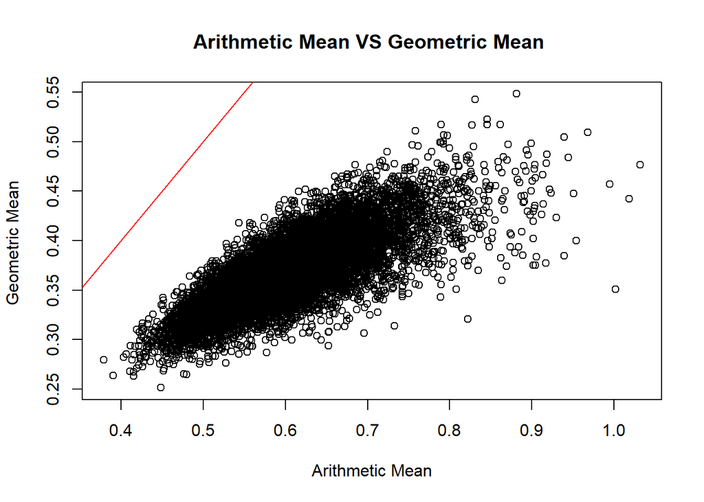

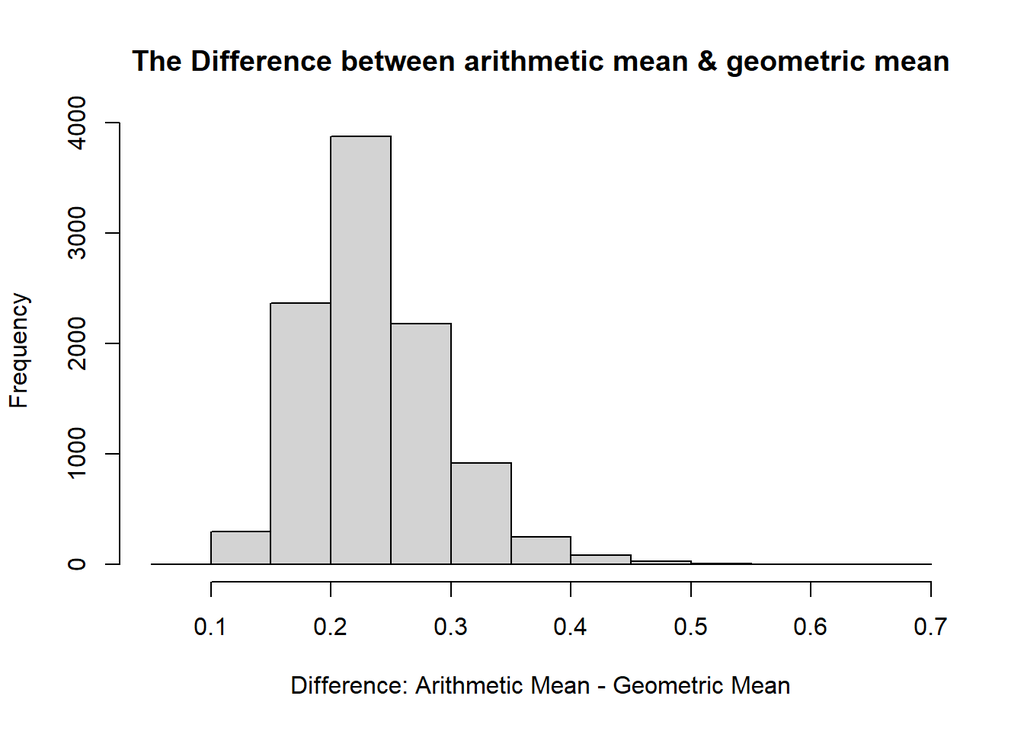

```r
lnorm34<-function(n,size,μ,σ){

x=as.data.frame(replicate(n,rlnorm(size,μ,σ)))

# arithmetic mean & ge mean
ar_mean <- colMeans(x)
ge_mean <- exp(colMeans(log(x)))

plot(x=ar_mean,y=ge_mean,main='Arithmetic Mean VS Geometric Mean ',xlab = "Arithmetic Mean",  ylab = "Geometric Mean ")
abline(0,1,col='red')

hist(ar_mean-ge_mean,main= 'The Difference between arithmetic mean & geometric mean',xlab='Difference: Arithmetic Mean - Geometric Mean')
}

lnorm34(10000,size=100,μ=-1,σ=1)
```

### Distribution 3

*X* ∼ UNIFORM(0, 12)

1. For uniform distribution,

$$Mean=\frac{a+b}{2}$$

```r
x3 <- seq(-2,14,0.01)
mean3 <- (0+12)/2
median3 <-qunif(0.5,0,12)
```

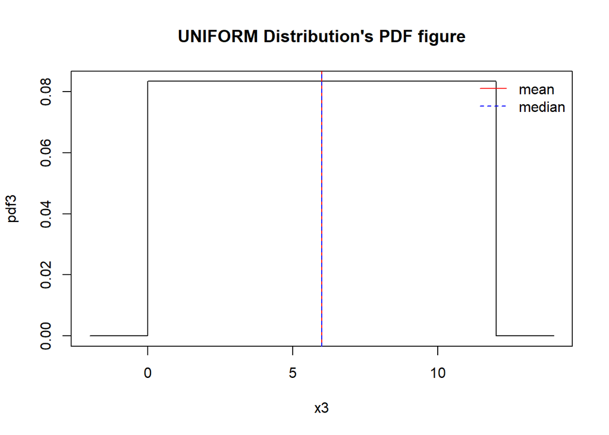

```r
pdf3 <- dunif(x3,0,12)

plot(x3,pdf3,main='UNIFORM Distribution\'s PDF figure',type='l')
abline(v=mean3,col='red')
abline(v=median3,col='blue',lty=2)
legend("topright",c("mean","median"),col=c("red","blue"),lty=c(1,2),bty = "n")
```

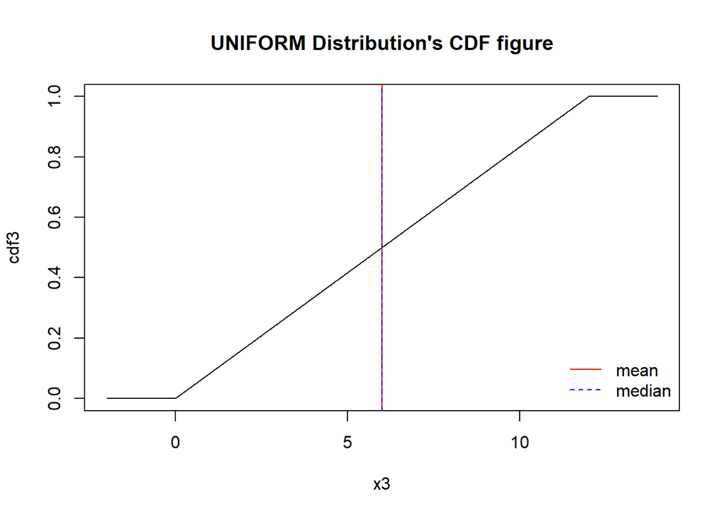

```r
cdf3 <- punif(x3,0,12)

plot(x3,cdf3,main='UNIFORM Distribution\'s CDF figure',type='l')
abline(v=mean3,col='red')
abline(v=median3,col='blue',lty=2)
legend("bottomright",c("mean","median"),col=c("red","blue"),lty=c(1,2),bty = "n")
```

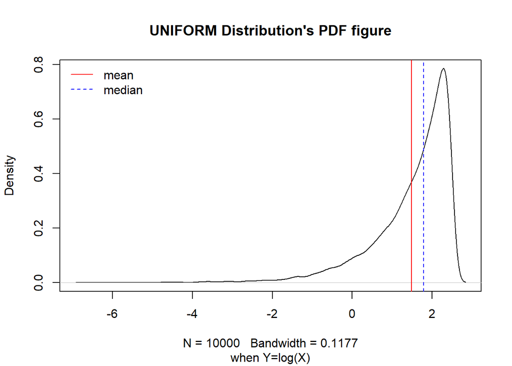

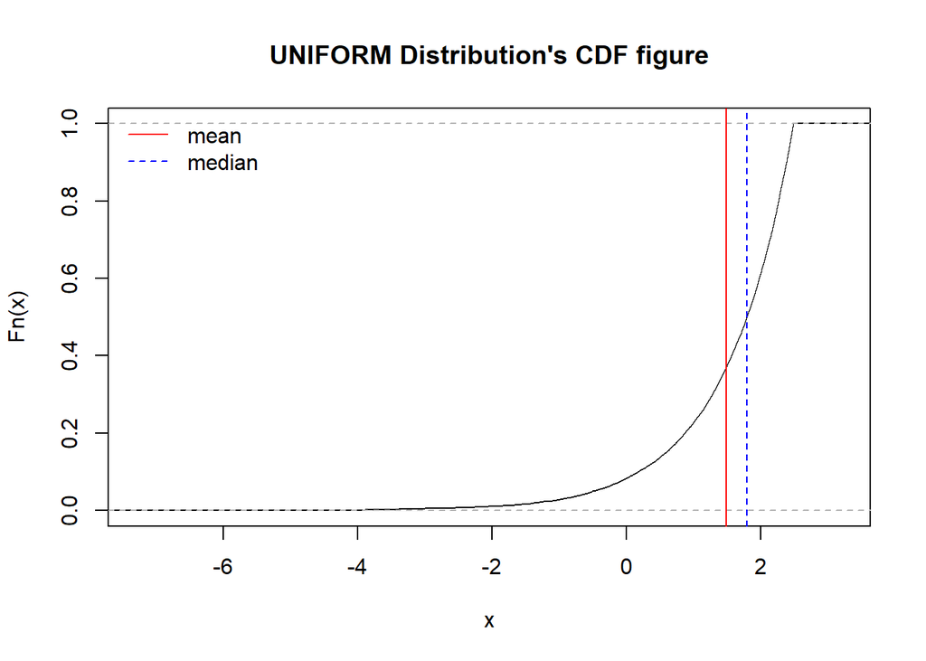

```r
unif2<-function(times,a,b,title1,title2){
X <- runif(times,a,b)
Y <- log(X)
plot(density(Y),type='l',main=title1,sub='when Y=log(X)')
abline(v=mean(Y),col='red')
abline(v=median(Y),col='blue',lty=2)
legend("topleft",c("mean","median"),col=c("red","blue"),lty=c(1,2),bty = "n")

plot(ecdf(Y),main=title2)
abline(v=mean(Y),col='red')
abline(v=median(Y),col='blue',lty=2)
legend("topleft",c("mean","median"),col=c("red","blue"),lty=c(1,2),bty = "n")
}

unif2(10000,a=0,b=12,title1='UNIFORM Distribution\'s PDF figure',title2='UNIFORM Distribution\'s CDF figure')
```

3 & 4.

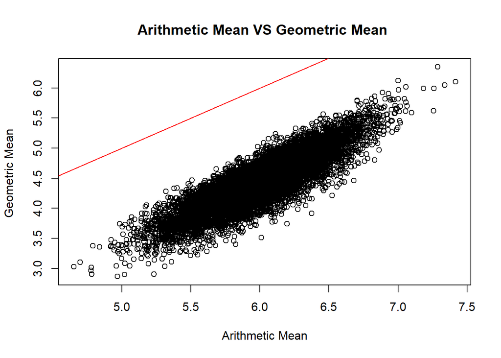

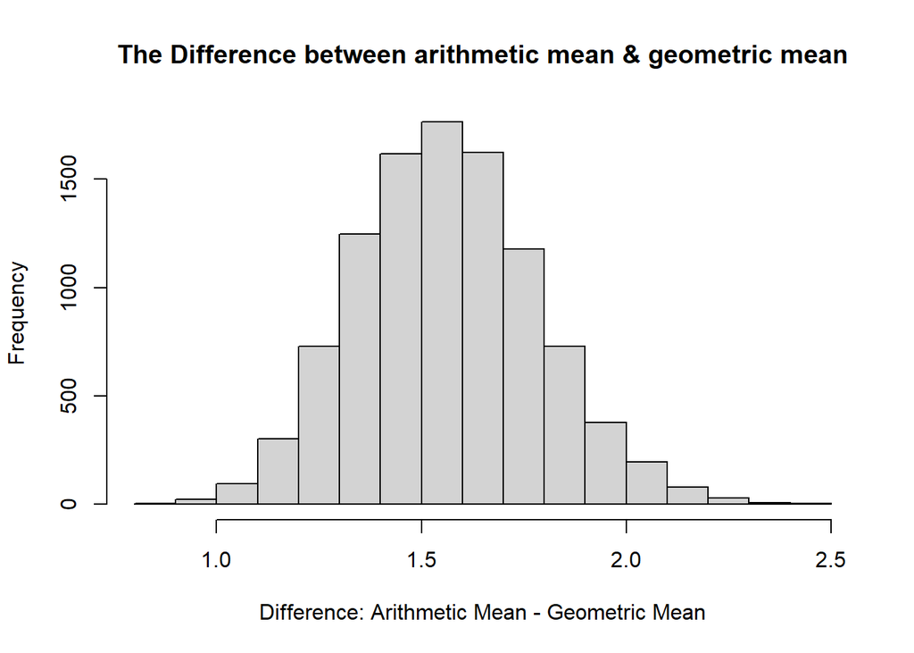

```r
unif34<-function(n,size,a,b){

x=as.data.frame(replicate(n,runif(size,a,b)))

# arithmetic mean & ge mean
ar_mean <- colMeans(x)
ge_mean <- exp(colMeans(log(x)))

plot(x=ar_mean,y=ge_mean,main='Arithmetic Mean VS Geometric Mean ',xlab = "Arithmetic Mean",  ylab = "Geometric Mean ")
abline(0,1,col='red')

hist(ar_mean-ge_mean,main= 'The Difference between arithmetic mean & geometric mean',xlab='Difference: Arithmetic Mean - Geometric Mean')
}

unif34(10000,size=100,a=0,b=12)
```

# Part 2 (OPTIONAL)

Show that if *X*<sub>*i*</sub> > 0 for all *i*, then the arithmetic mean is greater than or equal to the geometric mean.

**Answer**

```r
ans2<- function(number,i){
  ar_mean = NA
  ge_mean = NA
  for (n in 1:i){
    X=sample(number,i,replace=T)
    ar_mean[n]=mean(X)
    ge_mean[n]=exp(mean(log(X)))
}
  unique(ifelse(ar_mean >=ge_mean ,"Prove","Unprove"))
}
ans2(1000,1000)
```

```
## [1] "Prove"
```

According to the simulation above, we can know that: if *X*<sub>*i*</sub> > 0 for all *i*, then the arithmetic mean is greater than or equal to the geometric mean.

# Part 3

What is the correct relationship between `E[log(X)]` and `log(E[X])`? Is one always larger? Equal? Explain your answer.

**1. Analytic Answer**

Recall that:

$$e^x\geq 1+x$$

so,
$$E\left[e^{Y}\right]=e^{ E(Y)}E\left[e^{Y- E(Y)}\right]\geq e^{E(Y)} E\left[1+{Y- E(Y)}\right] = e^{E(Y)}$$
.

which means:

$$e^{E(Y)}\leq E\left[e^{Y}\right]$$

Now letting $Y=\log X$, we have:

$$e^{E(\log X)}\leq E\left[e^{\log X}\right]=E(X)$$

Now take logs of both sides, we get:

$$E[\log (X)]\leq\log[E(X)]$$

**Conclusion**

the relationship between `E[log(X)]` and `log(E[X])` is that: `E[log(X)]` always less or equal than `log(E[X])`

**2. Simulation Answer**

```r
ans3<- function(number,i){
  mean_log = NA
  log_mean = NA
   diff=NA
  for (n in 1:i){
    X=sample(number,i,replace=T)
    mean_log[n]=mean(log(X))
    log_mean[n]=log(mean(X))
    diff[n]=mean_log[n]-log_mean[n]
}
  if (max(diff)<0){
    print('E[log(X)] is always smaller than log(E[X])')
  }
   if (min(diff)>0){
     print('E[log(X)] is always larger than log(E[X])')
   }
}
ans3(1000,1000)
```

```
## [1] "E[log(X)] is always smaller than log(E[X])"
```

From the simulation above, we can find out that the max `E[log(X)] - log(E[X])` is always less than 0. So `log(E[X])` is always larger.